# Project_Ensemble_Banking_TD_Subscription

```python
def feature_target_analysis(feature,count):
    if feature!='Target':
        plt.figure(count,figsize=(8,6))
        if i in numerical_feature_list:
            nbins=(df[feature].max()-abs(df[feature].min()))/(np.std(df[feature]))
            new_feature=feature+'_Band'
            df[new_feature]=pd.qcut(x=df[feature],q=4,duplicates='drop')
            feature=new_feature
            feature_band_list.append(new_feature)
            sns.pointplot(x=feature,y='Target',data=df[['Target',feature]].groupby(by=feature,as_index=False).mean())
            plt.xticks(rotation=90)
        else:
            sns.pointplot(x=feature,y='Target',data=df[['Target',feature]].groupby(by=feature,as_index=False).mean())
            plt.xticks(rotation=90)
```

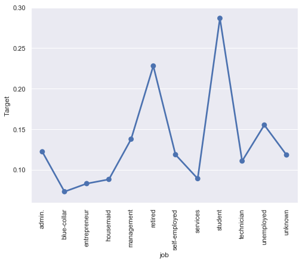

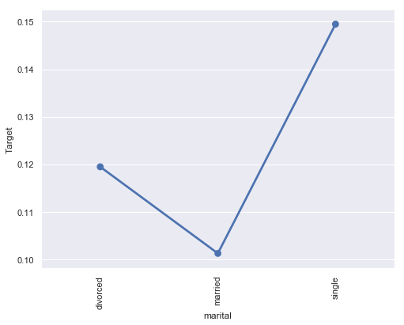

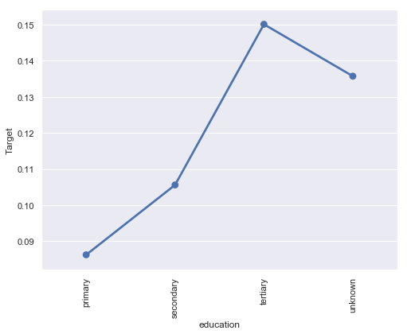

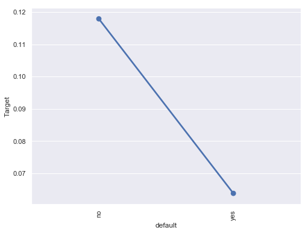

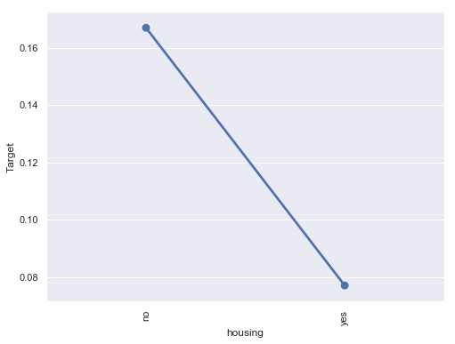

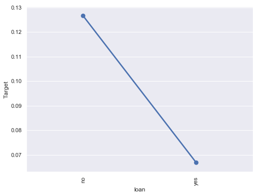

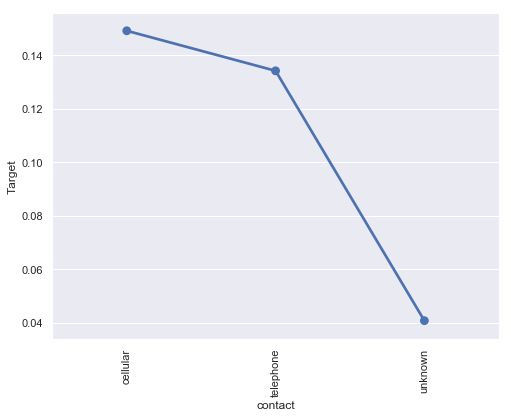

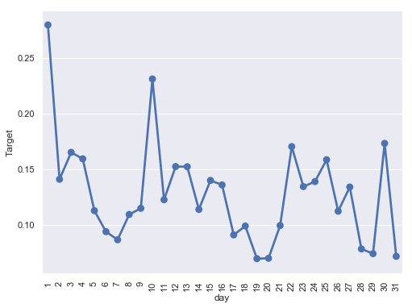

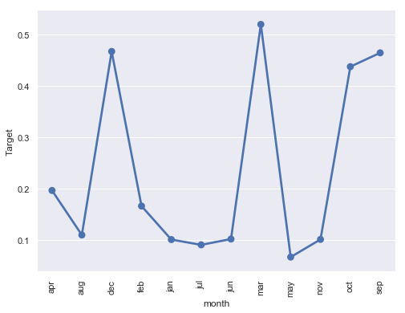

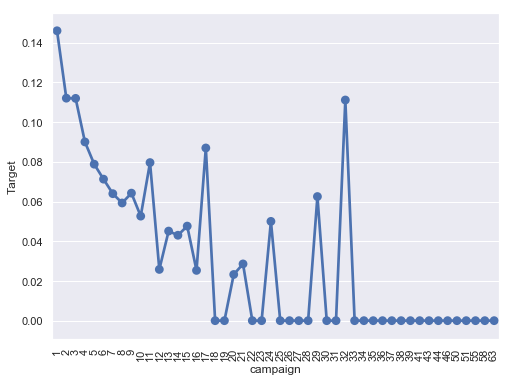

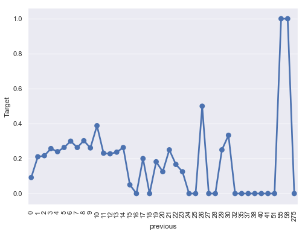

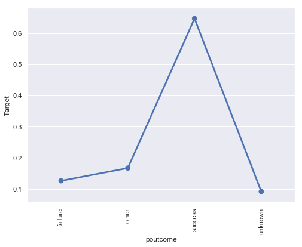

[4 more figures not shown]

```python
feature_band_list=[]
count=0
for i in categorical_feature_list+numerical_feature_list:
    count=count+1
    feature_target_analysis(i,count)
```

Observations:

job: Student are opting for TD more than any others. Next are retired and followed by unemployed(bit surprised). This observation can be because of less customer data for Student and retired.

marital: married Customers are not opting for TD compared to Single and divorced.

education: Customers with teritiary education are opting for TD compared to secondary and primary. This indicates that as Customer's level of education increases then more are perferring for TD.

default: comparitively customers with default 'no' are opting for TD.

housing: customers with 'no' housing loan are opting for TD compared with having housing loan.

loan: customers with 'no' personal loan are opting for TD compared with having personal loan.

contact: customers contacted through cellular are opting more for TD compared to telephone.

day: customers contacted on 1st and 10th are more likely to opt for TD. If we divide data into 3 sets each of 10 days then in first 10 days the opting rate is high followed by 2nd 10 days and then 3rd. If we split like this then we can see 3 straight lines fit with negative slopes.

month: customers last contacted in march and december are opting for TD compared to other months. However if we see how many times customers contacted in this month, those are very less. Hence this observation can be because of very less data.

campaign: Customers tend to opt for TD mostly with campaign values of 1,2 and then 3.

previous: Distribution doesnt seem to follow a particular trend. Its a bit upward trend till previous<10.

poutcome: customers with poutcome='success' tend to opt for TD more.

age: There is an upward trend of opting for TD for those customers whose age is more than 40. Younger generation and above middle age people are opting for TD more. This is in align with our analysis for feature job.

balance: Customers having balance to a certain amount are tend to opt for TD. Here we have so many outliers in the high balance. So this need to be checked.

duration: As duration increased then customers are opting for TD. This indicates that customers need to be engaged/contacted more.

pdays: More than 80% of customers are not contacted before. Hence the graph is pointing a single point indicating the last quantile.

### 4. Prepare the data to train a model – check if data types are appropriate, get rid of the missing values etc.

(15 marks)

#### Feature Selection

Below features are pointing to the current campaign(Target feature). These features are impossible to capture before starting the campaign.  
Hence there is no point in keeping these features in realistic model. These features can be used for deriving insights which we have already done above till now. Hence dropping those features from further stages:  
day  
month  
duration  
campaign

```python
# Dropping as per above analysis
df.drop(labels=['day','month','campaign','duration'],axis=1,inplace=True)
```

Features pdays & previous:  
These are referring to the same information. But in different manner.  
pdays - number of days that passed by after the client was last contacted from a previous campaign.  
previous - number of contacts performed before this campaign and for this client  
And the distribution of both features also points the same.

```python
# -1 indicates that customer is not contacted before. Same we have observed in our above univariate analysis
print(sum(df['pdays']==-1))

# 0 indicates that customer is not contacted before this campaign for this client
print(sum(df['previous']==0))
```

```
36954
36954
```

Instead of having two distributions with 82% of data pointing to single values in each, lets keep a single feature which can give the same information.

```python
df['pdays'].value_counts(normalize=True).head(5)
```

```
-1      0.817367
 182    0.003694
 92     0.003251
 183    0.002787
 91     0.002787
Name: pdays, dtype: float64
```

Decision:

Above clearly shows that 82% of the customers are not contacted before. This feature can be turned into categorical feature with values Yes/No where in:

'No' indicates that Customer was not contacted during the previous campaign.  
'Yes' indicates that customer was contacted during the previous campaign.

```python
# binning
# Converting feature duration into 4 quantile categories
df.loc[df['pdays']==-1,'pdays']='No'
df.loc[df['pdays']!='No','pdays']='Yes'

# Converting this into object as it can be deemed as categorical
df['pdays']=df['pdays'].astype('object')
```

```python
# Dropping as per above analysis
df.drop(labels=['previous'],axis=1,inplace=True)
```

Feature: default

As per above analysis, 98% of the data are of value No. Hence this cannot be of much helpful in predictions.

Decision: Remove the feature

```python
# Dropping as per above analysis
df.drop(labels=['default'],axis=1,inplace=True)
```

```python
# Removing the Band features created for analysis and understanding of data
df.drop(feature_band_list,inplace=True,axis=1)
```

Rest other features can be processed into next stages.

#### Outliers Treatment

As per all the above analysis, Outliers are present for below numerical features:

Feature: age  
Outliers are present in maximum. age above 70.5 are outliers and total are 487

Decision: By observing the above bivariate analysis performed between "age_Band vs Target", its clear that from age 40+ onwards there is an upward trend for TD opting. The same trend has been followed in outliers as well. Hence these outliers shouldnt be an impact in predicting the Target. Lets keep it. And inorder to reduce the high values of outliers, we can do binning.

```python
df[df['age']>70.5][['age','Target']].groupby(by='Target',as_index=False).count().sort_values(by='Target',ascending=False)
```

|  | Target | age |
| --- | --- | --- |
| 1 | 1 | 218 |
| 0 | 0 | 269 |

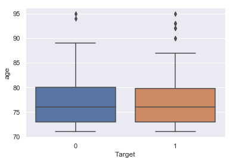

```python
sns.boxplot(y='age',x='Target',data= df[df['age']>70.5][['age','Target']])
```

Above states that data is almost evenly distributed between Target (1/0) for feature age outliers. Instead of deleting them, lets assign all the outliers who age is greater than the median age of the outliers to median. So this reduces skewness of the feature and helps in better prediction.

```python
# Get median age of the outliers
outlier_median_age=np.median(df[df['age']>70.5]['age'])
print(outlier_median_age)

# Replace all the outlier above the median value with this median
print("Skewness before: ", df['age'].skew())
df.loc[df['age']>outlier_median_age,'age']=outlier_median_age
print("Skewness after: ", df['age'].skew())
```

```
76.0
Skewness before:  0.6848179257252598
Skewness after:  0.6123168021418827
```

```python
# Check how many updates happend out of 487 outliers
sum(df['age']==outlier_median_age)
```

```
261
```

```python
# Applying log transformation on feature age to reduce skewness further

print("Skewness before: ", df['age'].skew())
df['age']=np.log(df['age'])
print("Skewness after: ", df['age'].skew())
```

```
Skewness before:  0.6123168021418827
Skewness after:  0.07562174806574452
```

Feature: balance  
Outliers are present in maximum. balance above 3462.0 are outliers and total are 4712  
Outliers are present in minimum. balance below -1962.0 are outliers and total are 17

Decision: As per above bivariate analysis between "balance_Band vs Target", itseems that outliers are also following the same trend as normal ones. Instead of removing these, we can do binning for this feature.

```python
df[df['balance']>3462][['balance','Target']].groupby(by='Target',as_index=False).count().sort_values(by='Target',ascending=False)
```

|  | Target | balance |
| --- | --- | --- |
| 1 | 1 | 766 |
| 0 | 0 | 3946 |

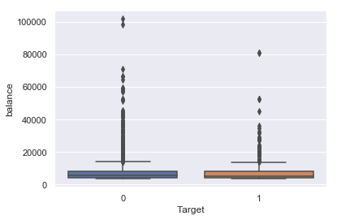

```python
sns.boxplot(y='balance',x='Target',data= df[df['balance']>3462][['balance','Target']])
```

Above states that data for Target 1/0 is almost overlapped w.r.t. feature balance outliers. Instead of deleting them, lets assign all these to a median balance of the outliers. So this reduces skewness of the feature and helps in better prediction.

```python
# Get median balance of the outliers
outlier_median_balance=np.median(df[df['balance']>3462]['balance'])
print(outlier_median_balance)

# Replace all the outlier above the median value with this median
print("Skewness before: ", df['balance'].skew())
df.loc[df['balance']>outlier_median_balance,'balance']=outlier_median_balance
print("Skewness after: ", df['balance'].skew())
```

```
5618.0
Skewness before:  8.360308326166326
Skewness after:  1.6845722062611845
```

```python
# Check how many updates happend out of 4712 outliers
sum(df['balance']==outlier_median_balance)
```

```
2357
```

```python
df[df['balance']<-1962][['balance','Target']].groupby(by='Target',as_index=False).count().sort_values(by='Target',ascending=False)
```

|  | Target | balance |
| --- | --- | --- |
| 1 | 1 | 1 |
| 0 | 0 | 16 |

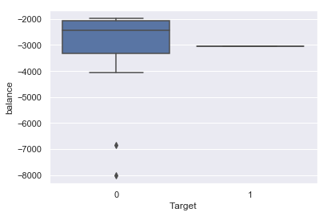

```python
sns.boxplot(y='balance',x='Target',data= df[df['balance']<-1962][['balance','Target']])
```

```python
# Get median balance of the outliers
outlier_median_balance=np.median(df[df['balance']<-1962]['balance'])
print(outlier_median_balance)

# Replace all the outlier above the median value with this median
df.loc[df['balance']<outlier_median_balance,'balance']=outlier_median_balance
```

```
-2604.0
```

```python
# Check how many updates happend out of 4712 outliers
sum(df['balance']==outlier_median_balance)
```

```
9
```

```python
# Since balance has negative and zero values, so applying cube root transformation to reduce skewness further

print("Skewness before: ", df['balance'].skew())
df['balance']=np.cbrt(df['balance'])
print("Skewness after: ", df['balance'].skew())
```

```
Skewness before:  1.6950437415050723
Skewness after:  -0.5071215014599088
```

```python
df.info()
```

```
<class 'pandas.core.frame.DataFrame'>
RangeIndex: 45211 entries, 0 to 45210
Data columns (total 11 columns):
age          45211 non-null float64
job          45211 non-null object
marital      45211 non-null object
education    45211 non-null object
balance      45211 non-null float64
housing      45211 non-null object
loan         45211 non-null object
contact      45211 non-null object
pdays        45211 non-null object
poutcome     45211 non-null object
Target       45211 non-null int64
dtypes: float64(2), int64(1), object(8)
memory usage: 3.8+ MB
```

#### Binning

```python
from collections import defaultdict
```

```python
# To convert less frequent occuring categories and grouping them as 'others'.
# uq_dict can help in saving the unique values which can be used for any upcoming new data
uq_dict=dict()
f_uq_cat_list=[]

for i in df.select_dtypes(include='object').columns:
    if i!='Target':
        if df[i].nunique()>4:
            dfv=df[i].value_counts(normalize=True)
            f_uq_cat_list=list(dfv.loc[(dfv>0.10)].index)
            if type(df.loc[0,i])==str:
                default='others'
            else:
                default=9999
            d=defaultdict(lambda: default)
            d.update({i:i for i in f_uq_cat_list})
            uq_dict[i]=dict(d)
            df[i]=df[i].map(d)
            df[i]=df[i].astype('object')
```

#### Approach

Below approach is followed in data prepartion:

1. Scale the continuous variables.
2. One hot encoding FIT for Categorical variables.
3. Split the dataset into train and test.
4. Use SMOTENC to generate synthetic data for Continuous and categorical features together.
5. One hot encoding TRANSFORMATION for train and test dataset.

Note: Above approach is followed to generate better synthetic data. If onehot transform is done before smotting then because of data sparsity(more columns) the synthetic data generated is not that great for models.

#### Scaling

```python
from sklearn.preprocessing import MinMaxScaler
```

```python
X=df[['age', 'balance']]

y=df['Target']
```

```python
mm_scale=MinMaxScaler()
mm_scale=mm_scale.fit(X)
X_scaled=pd.DataFrame(data=mm_scale.transform(X), columns=X.columns)
```

```python
X_scaled.head(5)
```

|  | age | balance |
| --- | --- | --- |
| 0 | 0.812346 | 0.845108 |
| 1 | 0.620551 | 0.533697 |
| 2 | 0.420822 | 0.476225 |
| 3 | 0.666344 | 0.799755 |
| 4 | 0.420822 | 0.467982 |

```python
# Concatenate categorical features back
X_scaled=pd.concat([X_scaled,df.select_dtypes(include='object')], axis=1)
```

#### OneHot Encoding Fit

```python
from sklearn.preprocessing import OneHotEncoder
```

```python
# Fit
ohe=OneHotEncoder(drop='first',dtype=np.int64)
ohe_object_list=list(df.select_dtypes(include='object'))
ohe=ohe.fit(X_scaled[ohe_object_list])
ohe_cat_list = ohe.get_feature_names(ohe_object_list)
```

#### Train and Test Split

```python
from sklearn.model_selection import train_test_split
```

```python
X_train,X_test,y_train,y_test=train_test_split(X_scaled,y,random_state=1,test_size=0.3,stratify=y)
```

#### Fixing Imbalanced Classficiation using SMOTENC

```python
from imblearn.over_sampling import SMOTENC,RandomOverSampler
from imblearn.under_sampling import RandomUnderSampler
```

```python
cat_list_idx=[]

for i in X_scaled.select_dtypes(include='object').columns:
    cat_list_idx.append(X_scaled.columns.get_loc(i))

print("Indexes of Categorical Variables: \n", cat_list_idx)
```

```
Indexes of Categorical Variables:
 [2, 3, 4, 5, 6, 7, 8, 9]
```

```python
sm=SMOTENC(categorical_features=cat_list_idx,sampling_strategy=0.35, random_state=1, k_neighbors=7, n_jobs=-1)
```

```python
X_train,y_train=sm.fit_resample(X_train,y_train)
```

```python
y_train.value_counts()
```

```
0    27945
1     9780
Name: Target, dtype: int64
```

```python
rus=RandomUnderSampler(sampling_strategy=0.9, random_state=1, replacement=False)
X_train,y_train=rus.fit_resample(X_train,y_train)
```

Note: Undersampling is not done for final model. Because on trying multiple sampling combination, felt that just oversampling using SMOTENC alone is giving better results for this model.

#### OneHot Encoding Transform

```python
# Train data
X_train[ohe_cat_list]=pd.DataFrame(data=ohe.transform(X_train[ohe_object_list]).toarray(),columns=ohe_cat_list,index=X_train.index)

# Test data
X_test[ohe_cat_list]=pd.DataFrame(data=ohe.transform(X_test[ohe_object_list]).toarray(),columns=ohe_cat_list,index=X_test.index)
```

```python
# Dropping the original features which are onehot encoded
X_train.drop(ohe_object_list,axis=1,inplace=True)
X_test.drop(ohe_object_list,axis=1,inplace=True)
```

```python
X_train.info()
```

```
<class 'pandas.core.frame.DataFrame'>
RangeIndex: 37725 entries, 0 to 37724
Data columns (total 19 columns):
age                    37725 non-null float64
balance                37725 non-null float64
job_blue-collar        37725 non-null int64
job_management         37725 non-null int64
job_others             37725 non-null int64
job_technician         37725 non-null int64
marital_married        37725 non-null int64
marital_single         37725 non-null int64
education_secondary    37725 non-null int64
education_tertiary     37725 non-null int64
education_unknown      37725 non-null int64
housing_yes            37725 non-null int64
loan_yes               37725 non-null int64
contact_telephone      37725 non-null int64
contact_unknown        37725 non-null int64
pdays_Yes              37725 non-null int64
poutcome_other         37725 non-null int64
poutcome_success       37725 non-null int64
poutcome_unknown       37725 non-null int64
dtypes: float64(2), int64(17)
memory usage: 5.5 MB
```

### 5. Train a few standard classification algorithms, note and comment on their performances across different classification metrics. (15 marks)

#### Metrics

Since its a imbalanced classification and even after smotting the minority class is only 35% of majority class. So metrics like accuracy are not helpful to select the best model. Below metrics are considered for this use case:

1. AUC - Can help in selecting optimal threshold where maximum difference between TPR and FPR
2. Recall score - Can help in selecting model where False Negatives are less.  
   False Negatives for minority class (Term Deposit Opting) means the customers want to opt for TD but our model predicted they are not in favor.
3. f1 score - Finally f1-score help in balancing both precision and recall.  
   If we consider just recall score then there is a high chance that we end up with low precision.  
   Lower precision would create more false positives which is an unnecessary burden on Customer service team.

```python
from sklearn.metrics import accuracy_score,confusion_matrix,classification_report,recall_score,f1_score,auc,roc_auc_score,roc_curve
from sklearn.preprocessing import binarize
```

```python
# Store performance of each model in this list
model_results=[]

# Creating a function which gives accuracy, recall, f1-score,AUC and optimal threshold values for a model
def model_pred_acc_auc(model,base_model=None):
    ytest_pred=model.predict(X_test)
    train_acc=accuracy_score(y_train,model.predict(X_train))
    test_acc=accuracy_score(y_test,ytest_pred)
    test_recall_score=recall_score(y_test,ytest_pred)
    test_f1_score=f1_score(y_test,ytest_pred)
    ytrain_pred_proba=model.predict_proba(X_train)[:,1]
    ytest_pred_proba=model.predict_proba(X_test)[:,1]
    fpr, tpr, thresholds = roc_curve(y_train, ytrain_pred_proba)
    th_df=pd.DataFrame({'FPR':fpr,'TPR':tpr,'TH':thresholds})
    idx=np.argmax(th_df['TPR']-th_df['FPR'])
    opt_th=th_df.iloc[idx]['TH']
    ytest_pred = binarize([ytest_pred_proba], opt_th)[0]
    test_f1_score_opt_th=f1_score(y_test,ytest_pred)
    test_recall_score_opt_th=recall_score(y_test,ytest_pred)
    test_acc_opt_th=accuracy_score(y_test,ytest_pred)
    train_auc=auc(fpr,tpr)
    test_auc=roc_auc_score(y_test,ytest_pred_proba)

    print("Training data accuracy before threshold change: ",train_acc)
    print("Testing data accuracy before threshold change: ",test_acc)
    print("Testing data Recall score before threshold change: ",test_recall_score)
    print("Testing data f1-score before threshold change: ",test_f1_score)
    print("Training data AUC: ",train_auc)
    print("Testing data AUC: ",test_auc)
    print("Optimal threshold is: ", opt_th )
    print("Testing data accuracy after threshold change: ",test_acc_opt_th)
    print("Testing data Recall score after threshold change: ",test_recall_score_opt_th)
    print("Testing data f1-score after threshold change: ",test_f1_score_opt_th)

    if base_model is None:
        model_results.append({model.__class__.__name__:[np.round(train_acc,4),
                                                        np.round(test_acc,4),
                                                        np.round(test_recall_score,4),
                                                        np.round(test_f1_score,4),
                                                        np.round(train_auc,4),
                                                        np.round(test_auc,4),
                                                        np.round(opt_th,4),
                                                        np.round(test_acc_opt_th,4),
                                                        np.round(test_recall_score_opt_th,4),
                                                        np.round(test_f1_score_opt_th,4)]})
    else:
        model_results.append({base_model.__class__.__name__+'-'+model.__class__.__name__:[np.round(train_acc,4),
                                                        np.round(test_acc,4),
                                                        np.round(test_recall_score,4),
                                                        np.round(test_f1_score,4),
                                                        np.round(train_auc,4),
                                                        np.round(test_auc,4),
                                                        np.round(opt_th,4),
                                                        np.round(test_acc_opt_th,4),
                                                        np.round(test_recall_score_opt_th,4),
                                                        np.round(test_f1_score_opt_th,4)]})
    return ytest_pred
```

#### Notations:

BFR_TH_TRAIN_ACC - Before Threshold Change Training Accuracy  
BFR_TH_TEST_ACC - Before Threshold Change Testing Accuracy  
BFR_TH_RECALL_SCORE - Before Threshold Change Recall score  
BFR_TH_F1_SCORE - Before Threshold Change f1-score  
TRAIN_AUC - Training data AUC  
TEST_AUC - Testing AUC  
OPT_TH - Optimal Threshold value at which maximum difference is present between TPR and FPR  
AFT_TH_TEST_ACC - After Threshold change Test Accuracy  
AFT_TH_RECALL_SCORE - After Threshold change Recall score  
AFT_TH_F1_SCORE - After Threshold change f1-score

#### Logistic Regression

```python
from sklearn.linear_model import LogisticRegression
from sklearn.model_selection import GridSearchCV
```

```python
logm=LogisticRegression()
log_params={'solver':['lbfgs','newton-cg','sag','saga'],'max_iter':[100,200,300,400,500,600,700],'C':[1,10,100]}
gs=GridSearchCV(estimator=logm,param_grid=log_params,scoring='roc_auc',n_jobs=-1,cv=5,verbose=1)
gs=gs.fit(X_train,y_train)
```

```
Fitting 5 folds for each of 84 candidates, totalling 420 fits
```

```
[Parallel(n_jobs=-1)]: Using backend LokyBackend with 4 concurrent workers.
[Parallel(n_jobs=-1)]: Done  42 tasks      | elapsed:    7.1s
[Parallel(n_jobs=-1)]: Done 192 tasks      | elapsed:   36.5s
[Parallel(n_jobs=-1)]: Done 420 out of 420 | elapsed:  1.6min finished
```

```python
log_model=gs.best_estimator_
log_model=log_model.fit(X_train,y_train)
log_model_ytest_pred=model_pred_acc_auc(model=log_model)
```

```
Training data accuracy before threshold change:  0.7848376408217362
Testing data accuracy before threshold change:  0.8874225892067237
Testing data Recall score before threshold change:  0.20163831127914303
Testing data f1-score before threshold change:  0.29533917858790953
Training data AUC:  0.7594836739271305
Testing data AUC:  0.7350424166798588
Optimal threshold is:  0.28703406743322835
Testing data accuracy after threshold change:  0.7325272780890593
Testing data Recall score after threshold change:  0.5916824196597353
Testing data f1-score after threshold change:  0.3410824555030875
```

```python
log_cm=confusion_matrix(y_true=y_test,y_pred=log_model_ytest_pred,labels=[1,0])
log_cmdf=pd.DataFrame(data=log_cm,columns=['Predict Yes','Predict No'],index=['Actual Yes','Actual No'])
log_cmdf
```

|  | Predict Yes | Predict No |
| --- | --- | --- |
| Actual Yes | 939 | 648 |
| Actual No | 2980 | 8997 |

```python
print(classification_report(y_true=y_test,y_pred=log_model_ytest_pred,target_names=['No','Yes']))
```

```
              precision    recall  f1-score   support

          No       0.93      0.75      0.83     11977
         Yes       0.24      0.59      0.34      1587

    accuracy                           0.73     13564
   macro avg       0.59      0.67      0.59     13564
weighted avg       0.85      0.73      0.77     13564
```

#### Naive Bayes

```python
from sklearn.naive_bayes import GaussianNB
```

```python
gnb_model=GaussianNB()
gnb_model=gnb_model.fit(X_train,y_train)
gnb_model_ytest_pred=model_pred_acc_auc(model=gnb_model)
```

```
Training data accuracy before threshold change:  0.7503247183565275
Testing data accuracy before threshold change:  0.8088322028900029
Testing data Recall score before threshold change:  0.3692501575299307
Testing data f1-score before threshold change:  0.31128818061088975
Training data AUC:  0.736495548332779
Testing data AUC:  0.7110355497059344
Optimal threshold is:  0.11079077618521589
Testing data accuracy after threshold change:  0.6614567974048953
Testing data Recall score after threshold change:  0.6540642722117203
Testing data f1-score after threshold change:  0.31133773245350926
```

```python
gnb_cm=confusion_matrix(y_true=y_test,y_pred=gnb_model_ytest_pred,labels=[1,0])
gnb_cmdf=pd.DataFrame(data=gnb_cm,columns=['Predict Yes','Predict No'],index=['Actual Yes','Actual No'])
gnb_cmdf
```

|  | Predict Yes | Predict No |
| --- | --- | --- |
| Actual Yes | 1038 | 549 |
| Actual No | 4043 | 7934 |

```python
print(classification_report(y_true=y_test,y_pred=gnb_model_ytest_pred,target_names=['No','Yes']))
```

```
              precision    recall  f1-score   support

          No       0.94      0.66      0.78     11977
         Yes       0.20      0.65      0.31      1587

    accuracy                           0.66     13564
   macro avg       0.57      0.66      0.54     13564
weighted avg       0.85      0.66      0.72     13564
```

#### KNearestNeighbours

```python
from sklearn.neighbors import KNeighborsClassifier
```

```python
knnm=KNeighborsClassifier()
knn_params={'n_neighbors' : [3,5,7,9,11,13,15], 'weights': ['uniform', 'distance']}
gs=GridSearchCV(estimator=knnm,param_grid=knn_params,scoring='roc_auc',n_jobs=-1,cv=5,verbose=1)
gs=gs.fit(X_train,y_train)
```

```
Fitting 5 folds for each of 14 candidates, totalling 70 fits
```

```
[Parallel(n_jobs=-1)]: Using backend LokyBackend with 4 concurrent workers.
[Parallel(n_jobs=-1)]: Done  42 tasks      | elapsed:  1.0min
[Parallel(n_jobs=-1)]: Done  70 out of  70 | elapsed:  1.7min finished
```

```python
knn_model=gs.best_estimator_
knn_model=knn_model.fit(X_train,y_train)
knn_model_ytest_pred=model_pred_acc_auc(model=knn_model)
```

```
Training data accuracy before threshold change:  0.9960768721007289
Testing data accuracy before threshold change:  0.8342671778236508
Testing data Recall score before threshold change:  0.3264020163831128
Testing data f1-score before threshold change:  0.315468940316687
Training data AUC:  0.9999546106670969
Testing data AUC:  0.6672864746698132
Optimal threshold is:  0.3333333333333333
Testing data accuracy after threshold change:  0.7702742553818932
Testing data Recall score after threshold change:  0.4417139256458727
Testing data f1-score after threshold change:  0.3103142983621071
```

```python
knn_cm=confusion_matrix(y_true=y_test,y_pred=knn_model_ytest_pred,labels=[1,0])
knn_cmdf=pd.DataFrame(data=knn_cm,columns=['Predict Yes','Predict No'],index=['Actual Yes','Actual No'])
knn_cmdf
```

|  | Predict Yes | Predict No |
| --- | --- | --- |
| Actual Yes | 701 | 886 |
| Actual No | 2230 | 9747 |

```python
print(classification_report(y_true=y_test,y_pred=knn_model_ytest_pred,target_names=['No','Yes']))
```

```
              precision    recall  f1-score   support

          No       0.92      0.81      0.86     11977
         Yes       0.24      0.44      0.31      1587

    accuracy                           0.77     13564
   macro avg       0.58      0.63      0.59     13564
weighted avg       0.84      0.77      0.80     13564
```

#### SVM

Tried SVM but its taking too much time to generate the results and if probability=True is set then its taking more time further. Hence omitting this model for comparision as we can not do ensemble as well if its taking more time.

#### Decision Tree

```python
from sklearn.tree import DecisionTreeClassifier
```

```python
dtree=DecisionTreeClassifier()
dtree_params={'criterion':['gini'],'max_depth':range(10,25,1)}
gs=GridSearchCV(estimator=dtree,param_grid=dtree_params,scoring='roc_auc',cv=5,verbose=1,n_jobs=-1)
gs=gs.fit(X_train,y_train)
```

```
Fitting 5 folds for each of 15 candidates, totalling 75 fits
```

```
[Parallel(n_jobs=-1)]: Using backend LokyBackend with 4 concurrent workers.
[Parallel(n_jobs=-1)]: Done  42 tasks      | elapsed:    6.0s
[Parallel(n_jobs=-1)]: Done  75 out of  75 | elapsed:    8.6s finished
```

```python
dtree_model=gs.best_estimator_
dtree_model=dtree_model.fit(X_train,y_train)
dtree_model_ytest_pred=model_pred_acc_auc(model=dtree_model)
```

```
Training data accuracy before threshold change:  0.8507090788601723
Testing data accuracy before threshold change:  0.8548363314656443
Testing data Recall score before threshold change:  0.295526149968494
Testing data f1-score before threshold change:  0.3226694186446509
Training data AUC:  0.890600787553407
Testing data AUC:  0.6766956294460411
Optimal threshold is:  0.2601626016260163
Testing data accuracy after threshold change:  0.7398997345915659
Testing data Recall score after threshold change:  0.516698172652804
Testing data f1-score after threshold change:  0.3173374613003096
```

```python
# Feature Importance
pd.DataFrame(data=dtree_model.feature_importances_,index=X_train.columns,columns=['features']).sort_values(by='features',ascending=False)
```

|  | features |
| --- | --- |
| poutcome_success | 0.259795 |
| age | 0.256344 |
| balance | 0.192577 |
| contact_unknown | 0.069584 |
| housing_yes | 0.044353 |
| loan_yes | 0.037248 |
| contact_telephone | 0.019326 |
| marital_single | 0.014597 |
| education_secondary | 0.013698 |
| education_tertiary | 0.013323 |
| job_others | 0.013226 |
| job_technician | 0.012284 |
| poutcome_unknown | 0.011365 |
| job_blue-collar | 0.010932 |
| marital_married | 0.008587 |
| job_management | 0.008263 |
| pdays_Yes | 0.005484 |
| education_unknown | 0.005451 |
| poutcome_other | 0.003562 |

```python
dtree_cm=confusion_matrix(y_true=y_test,y_pred=dtree_model_ytest_pred,labels=[1,0])
dtree_cmdf=pd.DataFrame(data=dtree_cm,columns=['Predict Yes','Predict No'],index=['Actual Yes','Actual No'])
dtree_cmdf
```

|  | Predict Yes | Predict No |
| --- | --- | --- |
| Actual Yes | 820 | 767 |
| Actual No | 2761 | 9216 |

```python
print(classification_report(y_true=y_test,y_pred=dtree_model_ytest_pred,target_names=['No','Yes']))
```

```
              precision    recall  f1-score   support

          No       0.92      0.77      0.84     11977
         Yes       0.23      0.52      0.32      1587

    accuracy                           0.74     13564
   macro avg       0.58      0.64      0.58     13564
weighted avg       0.84      0.74      0.78     13564
```

#### Comparision among base models

```python
modr_dict=dict()
for i in model_results:
    for k,v in i.items():
        modr_dict[k]=v
```

```python
modr_df=pd.DataFrame(data=modr_dict, index=['BFR_TH_TRAIN_ACC','BFR_TH_TEST_ACC','BFR_TH_RECALL_SCORE','BFR_TH_F1_SCORE',
                                                 'TRAIN_AUC','TEST_AUC','OPT_TH',
                                            'AFT_TH_TEST_ACC','AFT_TH_RECALL_SCORE','AFT_TH_F1_SCORE']).T
modr_df
```

|  | BFR_TH_TRAIN_ACC | BFR_TH_TEST_ACC | BFR_TH_RECALL_SCORE | BFR_TH_F1_SCORE | TRAIN_AUC | TEST_AUC | OPT_TH | AFT_TH_TEST_ACC | AFT_TH_RECALL_SCORE | AFT_TH_F1_SCORE |
| --- | --- | --- | --- | --- | --- | --- | --- | --- | --- | --- |
| LogisticRegression | 0.7848 | 0.8874 | 0.2016 | 0.2953 | 0.7595 | 0.7350 | 0.2871 | 0.7325 | 0.5917 | 0.3411 |
| GaussianNB | 0.7503 | 0.8088 | 0.3693 | 0.3113 | 0.7365 | 0.7110 | 0.1108 | 0.6615 | 0.6541 | 0.3113 |
| KNeighborsClassifier | 0.9961 | 0.8343 | 0.3264 | 0.3155 | 1.0000 | 0.6673 | 0.3333 | 0.7703 | 0.4417 | 0.3103 |
| DecisionTreeClassifier | 0.8507 | 0.8548 | 0.2955 | 0.3227 | 0.8906 | 0.6767 | 0.2602 | 0.7399 | 0.5167 | 0.3173 |

```python
# To retrieve the best model for each metric and its corresponding value for it
for i in ['AFT_TH_TEST_ACC','TEST_AUC','AFT_TH_RECALL_SCORE','AFT_TH_F1_SCORE']:
    print("Model with highest ",i," is : ",modr_df[i].sort_values(ascending=False).head(1).index.values[0]," & its value is: ",modr_df[i].sort_values(ascending=False).head(1)[0])
```

```
Model with highest  AFT_TH_TEST_ACC  is :  KNeighborsClassifier  & its value is:  0.7703
Model with highest  TEST_AUC  is :  LogisticRegression  & its value is:  0.735
Model with highest  AFT_TH_RECALL_SCORE  is :  GaussianNB  & its value is:  0.6541
Model with highest  AFT_TH_F1_SCORE  is :  LogisticRegression  & its value is:  0.3411
```

#### Final Decision:

Though KNN has highest accuracy, its AUC and f1-score are low compared to others. On a overall, taking AUC and f1-score into consideration, Logistic Regression is better compared to all. Because here, Logistic Regression has maintained all the metrics in equal priority. So its the first choice out of all base models.

### 6. Build the ensemble models and compare the results with the base models. Note: Random forest can be used only with Decision trees. (15 marks)

### Bagging Classifier

```python
from sklearn.ensemble import BaggingClassifier
```

```python
bgc_model=BaggingClassifier(n_estimators=50)
bgc_params={'base_estimator':[log_model,gnb_model,knn_model,None],'max_samples' : [0.7,0.8],'max_features':[0.7,0.8]}
gs=GridSearchCV(estimator=bgc_model,param_grid=bgc_params,scoring='roc_auc',n_jobs=-1,cv=4,verbose=1)
gs=gs.fit(X_train,y_train)
```

```
Fitting 4 folds for each of 16 candidates, totalling 64 fits
```

```
[Parallel(n_jobs=-1)]: Using backend LokyBackend with 4 concurrent workers.
[Parallel(n_jobs=-1)]: Done  42 tasks      | elapsed: 18.9min
[Parallel(n_jobs=-1)]: Done  64 out of  64 | elapsed: 25.1min finished
```

```python
gs.best_estimator_
```

```
BaggingClassifier(base_estimator=None, bootstrap=True, bootstrap_features=False,
                  max_features=0.7, max_samples=0.8, n_estimators=50,
                  n_jobs=None, oob_score=False, random_state=None, verbose=0,
                  warm_start=False)
```

Above states that, out of all Bagging Classifers for different base models, Decision Tree gives the best results.

```python
# Capturing GSCV results for bagging classifiers into DF.
bgc_gscv_df=pd.DataFrame(gs.cv_results_)
```

```python
bgc_gscv_df.head(10)
```

|  | mean_fit_time | std_fit_time | mean_score_time | std_score_time | param_base_estimator | param_max_features | param_max_samples | params | split0_test_score | split1_test_score | split2_test_score | split3_test_score | mean_test_score | std_test_score | rank_test_score |
| --- | --- | --- | --- | --- | --- | --- | --- | --- | --- | --- | --- | --- | --- | --- | --- |
| 0 | 80.031892 | 16.104224 | 0.029319 | 0.005785 | LogisticRegression(C=100, class_weight='None',... | 0.7 | 0.7 | {'base_estimator': LogisticRegression(C=100, c... | 0.732204 | 0.747108 | 0.762732 | 0.771482 | 0.753382 | 0.015024 | 12 |
| 1 | 78.645214 | 21.854072 | 0.027347 | 0.006766 | LogisticRegression(C=100, class_weight='None',... | 0.7 | 0.8 | {'base_estimator': LogisticRegression(C=100, c... | 0.730982 | 0.745605 | 0.763246 | 0.774799 | 0.753658 | 0.016718 | 11 |
| 2 | 95.728405 | 20.312435 | 0.066414 | 0.006767 | LogisticRegression(C=100, class_weight='None',... | 0.8 | 0.7 | {'base_estimator': LogisticRegression(C=100, c... | 0.729906 | 0.746773 | 0.766604 | 0.776153 | 0.754859 | 0.017884 | 10 |
| 3 | 94.422541 | 19.532213 | 0.077744 | 0.011608 | LogisticRegression(C=100, class_weight='None',... | 0.8 | 0.8 | {'base_estimator': LogisticRegression(C=100, c... | 0.730945 | 0.749024 | 0.765066 | 0.776574 | 0.755402 | 0.017179 | 9 |
| 4 | 1.220274 | 0.014047 | 0.263308 | 0.007669 | GaussianNB(priors=None, var_smoothing=1e-09) | 0.7 | 0.7 | {'base_estimator': GaussianNB(priors=None, var... | 0.718473 | 0.725392 | 0.747508 | 0.750589 | 0.735491 | 0.013820 | 13 |
| 5 | 1.218624 | 0.015780 | 0.255653 | 0.010467 | GaussianNB(priors=None, var_smoothing=1e-09) | 0.7 | 0.8 | {'base_estimator': GaussianNB(priors=None, var... | 0.715994 | 0.728441 | 0.742159 | 0.748874 | 0.733867 | 0.012677 | 14 |
| 6 | 1.380794 | 0.022637 | 0.332067 | 0.006769 | GaussianNB(priors=None, var_smoothing=1e-09) | 0.8 | 0.7 | {'base_estimator': GaussianNB(priors=None, var... | 0.711500 | 0.725165 | 0.746698 | 0.750335 | 0.733424 | 0.015899 | 16 |
| 7 | 1.404624 | 0.059578 | 0.328677 | 0.002483 | GaussianNB(priors=None, var_smoothing=1e-09) | 0.8 | 0.8 | {'base_estimator': GaussianNB(priors=None, var... | 0.715190 | 0.724180 | 0.743377 | 0.751298 | 0.733511 | 0.014461 | 15 |
| 8 | 44.047977 | 4.032783 | 179.570818 | 5.168890 | KNeighborsClassifier(algorithm='auto', leaf_si... | 0.7 | 0.7 | {'base_estimator': KNeighborsClassifier(algori... | 0.805600 | 0.851577 | 0.889918 | 0.901760 | 0.862214 | 0.037582 | 8 |
| 9 | 76.702789 | 3.633900 | 202.543704 | 2.479835 | KNeighborsClassifier(algorithm='auto', leaf_si... | 0.7 | 0.8 | {'base_estimator': KNeighborsClassifier(algori... | 0.818116 | 0.850056 | 0.892791 | 0.898221 | 0.864796 | 0.032777 | 7 |

```python
# Getting the best params of Bagging Classifers for each base model. Here there are two params: max_samples and max_features

bgc_max_samples_dict={}
bgc_max_features_dict={}

for i in bgc_gscv_df['param_base_estimator'].unique():
    if i is None:
        bgc_max_samples_dict['DecisionTreeClassifier']=bgc_gscv_df[bgc_gscv_df['param_base_estimator'].isna()].sort_values(by='rank_test_score')['param_max_samples'].iloc[0]
        bgc_max_features_dict['DecisionTreeClassifier']=bgc_gscv_df[bgc_gscv_df['param_base_estimator'].isna()].sort_values(by='rank_test_score')['param_max_features'].iloc[0]
    else:
        bgc_max_samples_dict[i.__class__.__name__]=bgc_gscv_df[bgc_gscv_df['param_base_estimator']==i].sort_values(by='rank_test_score')['param_max_samples'].iloc[0]
        bgc_max_features_dict[i.__class__.__name__]=bgc_gscv_df[bgc_gscv_df['param_base_estimator']==i].sort_values(by='rank_test_score')['param_max_features'].iloc[0]

print(bgc_max_samples_dict)
print(bgc_max_features_dict)
```

```
{'LogisticRegression': 0.8, 'GaussianNB': 0.7, 'KNeighborsClassifier': 0.8, 'DecisionTreeClassifier': 0.8}
{'LogisticRegression': 0.8, 'GaussianNB': 0.7, 'KNeighborsClassifier': 0.8, 'DecisionTreeClassifier': 0.7}
```

Above params are the best params w.r.t. each base model for bagging classifiers. Lets try these params and see.

#### base_estimatar: Logistic Regression

```python
n_estimators=400
base_model_name='LogisticRegression'
max_samples=bgc_max_samples_dict[base_model_name]
max_features=bgc_max_features_dict[base_model_name]
base_estimator=log_model
bgc_log_model=BaggingClassifier(base_estimator=base_estimator,n_estimators=n_estimators,max_samples=max_samples,max_features=max_features,n_jobs=-1,random_state=1,verbose=0)
#bgc_log_model=BaggingClassifier(base_estimator=log_model,n_estimators=300,n_jobs=-1,random_state=1,verbose=1)
bgc_log_model.fit(X_train,y_train)
bgc_log_model_ytest_pred=model_pred_acc_auc(model=bgc_log_model,base_model=base_estimator)
```

```
Training data accuracy before threshold change:  0.784519549370444
Testing data accuracy before threshold change:  0.8894131524624005
Testing data Recall score before threshold change:  0.18714555765595464
Testing data f1-score before threshold change:  0.2836676217765043
Training data AUC:  0.756587710083457
Testing data AUC:  0.7348850051235042
Optimal threshold is:  0.27943839974331913
Testing data accuracy after threshold change:  0.7239015039811265
Testing data Recall score after threshold change:  0.6112161310649024
Testing data f1-score after threshold change:  0.34124890061565527
```

```python
bgc_log_cm=confusion_matrix(y_true=y_test,y_pred=bgc_log_model_ytest_pred,labels=[1,0])
bgc_log_cmdf=pd.DataFrame(data=bgc_log_cm,columns=['Predict Yes','Predict No'],index=['Actual Yes','Actual No'])
bgc_log_cmdf
```

|  | Predict Yes | Predict No |
| --- | --- | --- |
| Actual Yes | 970 | 617 |
| Actual No | 3128 | 8849 |

```python
print(classification_report(y_true=y_test,y_pred=bgc_log_model_ytest_pred,target_names=['No','Yes']))
```

```
              precision    recall  f1-score   support

          No       0.93      0.74      0.83     11977
         Yes       0.24      0.61      0.34      1587

    accuracy                           0.72     13564
   macro avg       0.59      0.68      0.58     13564
weighted avg       0.85      0.72      0.77     13564
```

#### base_estimatar: Naive Bayes

```python
n_estimators=400
base_model_name='GaussianNB'
max_samples=bgc_max_samples_dict[base_model_name]
max_features=bgc_max_features_dict[base_model_name]
base_estimator=gnb_model
bgc_gnb_model=BaggingClassifier(base_estimator=base_estimator,n_estimators=n_estimators,max_samples=max_samples,max_features=max_features,n_jobs=-1,random_state=1,verbose=0)
bgc_gnb_model.fit(X_train,y_train)
bgc_gnb_model_ytest_pred=model_pred_acc_auc(model=bgc_gnb_model,base_model=base_estimator)
```

```
Training data accuracy before threshold change:  0.7530019880715706
Testing data accuracy before threshold change:  0.821217929814214
Testing data Recall score before threshold change:  0.3295526149968494
Testing data f1-score before threshold change:  0.30135407663497554
Training data AUC:  0.733610082030105
Testing data AUC:  0.7123590010447982
Optimal threshold is:  0.2005870671053688
Testing data accuracy after threshold change:  0.6711884399882041
Testing data Recall score after threshold change:  0.6357908002520479
Testing data f1-score after threshold change:  0.31151589996912626
```

```python
bgc_gnb_cm=confusion_matrix(y_true=y_test,y_pred=bgc_gnb_model_ytest_pred,labels=[1,0])
bgc_gnb_cmdf=pd.DataFrame(data=bgc_gnb_cm,columns=['Predict Yes','Predict No'],index=['Actual Yes','Actual No'])
bgc_gnb_cmdf
```

|  | Predict Yes | Predict No |
| --- | --- | --- |
| Actual Yes | 1009 | 578 |
| Actual No | 3882 | 8095 |

```python
print(classification_report(y_true=y_test,y_pred=bgc_gnb_model_ytest_pred,target_names=['No','Yes']))
```

```
              precision    recall  f1-score   support

          No       0.93      0.68      0.78     11977
         Yes       0.21      0.64      0.31      1587

    accuracy                           0.67     13564
   macro avg       0.57      0.66      0.55     13564
weighted avg       0.85      0.67      0.73     13564
```

#### base_estimatar: KNearest Neighbors

```python
n_estimators=200
base_model_name='KNeighborsClassifier'
max_samples=bgc_max_samples_dict[base_model_name]
max_features=bgc_max_features_dict[base_model_name]
base_estimator=knn_model
bgc_knn_model=BaggingClassifier(base_estimator=base_estimator,n_estimators=n_estimators,max_samples=max_samples,max_features=max_features,n_jobs=-1,random_state=1,verbose=0)
bgc_knn_model.fit(X_train,y_train)
bgc_knn_model_ytest_pred=model_pred_acc_auc(model=bgc_knn_model,base_model=base_estimator)
```

```
Training data accuracy before threshold change:  0.9863750828363155
Testing data accuracy before threshold change:  0.8751843114125627
Testing data Recall score before threshold change:  0.2495274102079395
Testing data f1-score before threshold change:  0.3187122736418511
Training data AUC:  0.9992288606637124
Testing data AUC:  0.7184367601439832
Optimal threshold is:  0.3868483197742558
Testing data accuracy after threshold change:  0.851002654084341
Testing data Recall score after threshold change:  0.34908632640201637
Testing data f1-score after threshold change:  0.35410674336848835
```

```python
bgc_knn_cm=confusion_matrix(y_true=y_test,y_pred=bgc_knn_model_ytest_pred,labels=[1,0])
bgc_knn_cmdf=pd.DataFrame(data=bgc_knn_cm,columns=['Predict Yes','Predict No'],index=['Actual Yes','Actual No'])
bgc_knn_cmdf
```

|  | Predict Yes | Predict No |
| --- | --- | --- |
| Actual Yes | 554 | 1033 |
| Actual No | 988 | 10989 |

```python
print(classification_report(y_true=y_test,y_pred=bgc_knn_model_ytest_pred,target_names=['No','Yes']))
```

```
              precision    recall  f1-score   support

          No       0.91      0.92      0.92     11977
         Yes       0.36      0.35      0.35      1587

    accuracy                           0.85     13564
   macro avg       0.64      0.63      0.63     13564
weighted avg       0.85      0.85      0.85     13564
```

#### base_estimatar: Decision Tree

```python
n_estimators=100
base_model_name='DecisionTreeClassifier'
max_samples=bgc_max_samples_dict[base_model_name]
max_features=bgc_max_features_dict[base_model_name]
base_estimator=DecisionTreeClassifier()
bgc_dtree_model=BaggingClassifier(base_estimator=base_estimator,n_estimators=n_estimators,max_samples=max_samples,max_features=max_features,n_jobs=-1,random_state=1,verbose=0)
bgc_dtree_model.fit(X_train,y_train)
bgc_dtree_model_ytest_pred=model_pred_acc_auc(model=bgc_dtree_model,base_model=base_estimator)
```

```
Training data accuracy before threshold change:  0.9734658714380384
Testing data accuracy before threshold change:  0.8836626363904453
Testing data Recall score before threshold change:  0.21613106490233144
Testing data f1-score before threshold change:  0.3030035335689046
Training data AUC:  0.9987192560906045
Testing data AUC:  0.7105077317115734
Optimal threshold is:  0.3490963611092599
Testing data accuracy after threshold change:  0.8540253612503687
Testing data Recall score after threshold change:  0.3333333333333333
Testing data f1-score after threshold change:  0.34825543120474
```

```python
bgc_dtree_cm=confusion_matrix(y_true=y_test,y_pred=bgc_dtree_model_ytest_pred,labels=[1,0])
bgc_dtree_cmdf=pd.DataFrame(data=bgc_dtree_cm,columns=['Predict Yes','Predict No'],index=['Actual Yes','Actual No'])
bgc_dtree_cmdf
```

|  | Predict Yes | Predict No |
| --- | --- | --- |
| Actual Yes | 529 | 1058 |
| Actual No | 922 | 11055 |

```python
print(classification_report(y_true=y_test,y_pred=bgc_dtree_model_ytest_pred,target_names=['No','Yes']))
```

```
              precision    recall  f1-score   support

          No       0.91      0.92      0.92     11977
         Yes       0.36      0.33      0.35      1587

    accuracy                           0.85     13564
   macro avg       0.64      0.63      0.63     13564
weighted avg       0.85      0.85      0.85     13564
```

#### Random Forest Classifier

```python
from sklearn.ensemble import RandomForestClassifier
```

```python
rfcm=RandomForestClassifier()
rfc_params={'n_estimators' : [100,200,300,400]}
gs=GridSearchCV(estimator=rfcm,param_grid=rfc_params,scoring='roc_auc',n_jobs=-1,cv=5,verbose=1)
gs=gs.fit(X_train,y_train)
```

```
Fitting 5 folds for each of 4 candidates, totalling 20 fits
```

```
[Parallel(n_jobs=-1)]: Using backend LokyBackend with 4 concurrent workers.
[Parallel(n_jobs=-1)]: Done  20 out of  20 | elapsed:  1.3min finished
```

```python
pd.DataFrame(gs.cv_results_)
```

|  | mean_fit_time | std_fit_time | mean_score_time | std_score_time | param_n_estimators | params | split0_test_score | split1_test_score | split2_test_score | split3_test_score | split4_test_score | mean_test_score | std_test_score | rank_test_score |
| --- | --- | --- | --- | --- | --- | --- | --- | --- | --- | --- | --- | --- | --- | --- |
| 0 | 5.392456 | 0.155128 | 0.312983 | 0.006451 | 100 | {'n_estimators': 100} | 0.815970 | 0.817218 | 0.913316 | 0.908943 | 0.909029 | 0.872895 | 0.045999 | 4 |
| 1 | 10.853119 | 0.185988 | 0.572156 | 0.010617 | 200 | {'n_estimators': 200} | 0.815977 | 0.818656 | 0.913833 | 0.908935 | 0.910536 | 0.873587 | 0.045980 | 3 |
| 2 | 16.072500 | 0.490660 | 0.965836 | 0.118350 | 300 | {'n_estimators': 300} | 0.815991 | 0.819221 | 0.914387 | 0.908891 | 0.910760 | 0.873850 | 0.045968 | 2 |
| 3 | 21.365986 | 2.116914 | 1.105665 | 0.206504 | 400 | {'n_estimators': 400} | 0.817477 | 0.819167 | 0.914760 | 0.910490 | 0.909838 | 0.874346 | 0.045778 | 1 |

AUC above 90% is most likely a overfit and when model was built with estimators 300 then accuracy is almost 100%. So trying to tune only to an extent where this overfitting can be reduced.

```python
rfcm=gs.best_estimator_
rfc_params={'max_samples':[0.9,0.8,0.7],'max_depth':range(15,25)}
gs=GridSearchCV(estimator=rfcm,param_grid=rfc_params,scoring='roc_auc',n_jobs=-1,cv=5,verbose=1)
gs=gs.fit(X_train,y_train)
```

```
Fitting 5 folds for each of 30 candidates, totalling 150 fits
```

```
[Parallel(n_jobs=-1)]: Using backend LokyBackend with 4 concurrent workers.
[Parallel(n_jobs=-1)]: Done  42 tasks      | elapsed:  3.3min
[Parallel(n_jobs=-1)]: Done 150 out of 150 | elapsed: 12.0min finished
```

```python
rfcm=gs.best_estimator_
rfc_params={'max_samples':[0.7],'max_depth':[24]}
gs=GridSearchCV(estimator=rfcm,param_grid=rfc_params,scoring='roc_auc',n_jobs=-1,cv=5,verbose=1)
gs=gs.fit(X_train,y_train)
```

```
Fitting 5 folds for each of 1 candidates, totalling 5 fits
```

```
[Parallel(n_jobs=-1)]: Using backend LokyBackend with 4 concurrent workers.
[Parallel(n_jobs=-1)]: Done   5 out of   5 | elapsed:   32.6s finished
```

```python
pd.DataFrame(gs.cv_results_)
```

[output not shown]

```python
rfc_model=gs.best_estimator_
rfc_model.fit(X_train,y_train)
rfc_model_ytest_pred=model_pred_acc_auc(model=rfc_model)
```

```
Training data accuracy before threshold change:  0.9835122597746853
Testing data accuracy before threshold change:  0.857711589501622
Testing data Recall score before threshold change:  0.2810333963453056
Testing data f1-score before threshold change:  0.31608788093550677
Training data AUC:  0.9989671100222062
Testing data AUC:  0.6992682204008008
Optimal threshold is:  0.42003926390014457
Testing data accuracy after threshold change:  0.8380271306399292
Testing data Recall score after threshold change:  0.3440453686200378
Testing data f1-score after threshold change:  0.3320158102766798
```

```python
rfc_cm=confusion_matrix(y_true=y_test,y_pred=rfc_model_ytest_pred,labels=[1,0])
rfc_cmdf=pd.DataFrame(data=rfc_cm,columns=['Predict Yes','Predict No'],index=['Actual Yes','Actual No'])
rfc_cmdf
```

|  | Predict Yes | Predict No |
| --- | --- | --- |
| Actual Yes | 546 | 1041 |
| Actual No | 1156 | 10821 |

```python
print(classification_report(y_true=y_test,y_pred=rfc_model_ytest_pred,target_names=['No','Yes']))
```

```
              precision    recall  f1-score   support

          No       0.91      0.90      0.91     11977
         Yes       0.32      0.34      0.33      1587

    accuracy                           0.84     13564
   macro avg       0.62      0.62      0.62     13564
weighted avg       0.84      0.84      0.84     13564
```

### Boosting

#### Adaptive Boosting

```python
from sklearn.ensemble import AdaBoostClassifier
```

```python
# Excluding KNN model because it doesnt support sample weighing. Adaboost allows only estimators which supports sample weights
ada=AdaBoostClassifier()
# None is for default decision tree(stump)
ada_params={'base_estimator':[log_model,gnb_model,None],'n_estimators':[100,200,300,400,500],'learning_rate':[0.5]}
gs=GridSearchCV(estimator=ada,param_grid=ada_params,scoring='roc_auc',cv=3,verbose=1,n_jobs=-1)
gs=gs.fit(X_train,y_train)
```

```
Fitting 3 folds for each of 15 candidates, totalling 45 fits
```

```
[Parallel(n_jobs=-1)]: Using backend LokyBackend with 4 concurrent workers.
[Parallel(n_jobs=-1)]: Done  45 out of  45 | elapsed: 231.4min finished
```

```python
ada_gscv_df=pd.DataFrame(gs.cv_results_)
```

```python
ada_gscv_df.head(5)
```

|  | mean_fit_time | std_fit_time | mean_score_time | std_score_time | param_base_estimator | param_learning_rate | param_n_estimators | params | split0_test_score | split1_test_score | split2_test_score | mean_test_score | std_test_score | rank_test_score |
| --- | --- | --- | --- | --- | --- | --- | --- | --- | --- | --- | --- | --- | --- | --- |
| 0 | 1132.354366 | 0.304259 | 0.145850 | 7.364572e-03 | LogisticRegression(C=100, class_weight='None',... | 0.5 | 100 | {'base_estimator': LogisticRegression(C=100, c... | 0.717882 | 0.769865 | 0.776160 | 0.754636 | 0.026115 | 10 |
| 1 | 2241.731170 | 2.969274 | 0.265656 | 1.988410e-06 | LogisticRegression(C=100, class_weight='None',... | 0.5 | 200 | {'base_estimator': LogisticRegression(C=100, c... | 0.717862 | 0.769903 | 0.776175 | 0.754647 | 0.026136 | 9 |
| 2 | 3441.915580 | 50.762291 | 0.454768 | 1.884378e-02 | LogisticRegression(C=100, class_weight='None',... | 0.5 | 300 | {'base_estimator': LogisticRegression(C=100, c... | 0.717854 | 0.769940 | 0.776191 | 0.754662 | 0.026152 | 8 |
| 3 | 4686.309415 | 37.509666 | 0.531307 | 2.973602e-07 | LogisticRegression(C=100, class_weight='None',... | 0.5 | 400 | {'base_estimator': LogisticRegression(C=100, c... | 0.717848 | 0.769965 | 0.776209 | 0.754674 | 0.026164 | 7 |
| 4 | 5057.473291 | 328.303783 | 0.615304 | 1.164514e-01 | LogisticRegression(C=100, class_weight='None',... | 0.5 | 500 | {'base_estimator': LogisticRegression(C=100, c... | 0.717843 | 0.769983 | 0.776226 | 0.754684 | 0.026175 | 6 |

```python
gs.best_estimator_
```

```
AdaBoostClassifier(algorithm='SAMME.R', base_estimator=None, learning_rate=0.5,
                   n_estimators=500, random_state=None)
```

Above states that out of all base models, dtree is the best model with boosting.

```python
# Getting the best params of Ada Boost Classifers for each base model. Here there are two params: n_estimator and learning_rate

ada_n_estimator_dict={}
ada_learning_rate_dict={}

for i in ada_gscv_df['param_base_estimator'].unique():
    if i is None:
        ada_n_estimator_dict['DecisionTreeClassifier']=ada_gscv_df[ada_gscv_df['param_base_estimator'].isna()].sort_values(by='rank_test_score')['param_n_estimators'].iloc[0]
        ada_learning_rate_dict['DecisionTreeClassifier']=ada_gscv_df[ada_gscv_df['param_base_estimator'].isna()].sort_values(by='rank_test_score')['param_learning_rate'].iloc[0]
    else:
        ada_n_estimator_dict[i.__class__.__name__]=ada_gscv_df[ada_gscv_df['param_base_estimator']==i].sort_values(by='rank_test_score')['param_n_estimators'].iloc[0]
        ada_learning_rate_dict[i.__class__.__name__]=ada_gscv_df[ada_gscv_df['param_base_estimator']==i].sort_values(by='rank_test_score')['param_learning_rate'].iloc[0]

print(ada_n_estimator_dict)
print(ada_learning_rate_dict)
```

```
{'LogisticRegression': 500, 'GaussianNB': 100, 'DecisionTreeClassifier': 500}
{'LogisticRegression': 0.5, 'GaussianNB': 0.5, 'DecisionTreeClassifier': 0.5}
```

Above params are the best params w.r.t. each base model for Ada Boost classifiers. Lets try these params and see.

#### base_estimatar: Logistic Regression

```python
base_model_name='LogisticRegression'
n_estimators=int(ada_n_estimator_dict[base_model_name]/2)
learning_rate=ada_learning_rate_dict[base_model_name]*2
base_estimator=log_model
ada_log_model=AdaBoostClassifier(base_estimator=base_estimator,n_estimators=n_estimators,learning_rate=learning_rate,random_state=1)
ada_log_model.fit(X_train,y_train)
ada_log_model_ytest_pred=model_pred_acc_auc(model=ada_log_model,base_model=base_estimator)
```

```
Training data accuracy before threshold change:  0.784387011265739
Testing data accuracy before threshold change:  0.8895606015924507
Testing data Recall score before threshold change:  0.19155639571518587
Testing data f1-score before threshold change:  0.288698955365622
Training data AUC:  0.7590041057130553
Testing data AUC:  0.733883873938386
Optimal threshold is:  0.49906177754461833
Testing data accuracy after threshold change:  0.7225007372456502
Testing data Recall score after threshold change:  0.5998739760554506
Testing data f1-score after threshold change:  0.3359209597741708
```

```python
ada_log_cm=confusion_matrix(y_true=y_test,y_pred=ada_log_model_ytest_pred,labels=[1,0])
ada_log_cmdf=pd.DataFrame(data=ada_log_cm,columns=['Predict Yes','Predict No'],index=['Actual Yes','Actual No'])
ada_log_cmdf
```

|  | Predict Yes | Predict No |
| --- | --- | --- |
| Actual Yes | 952 | 635 |
| Actual No | 3129 | 8848 |

```python
print(classification_report(y_true=y_test,y_pred=ada_log_model_ytest_pred,target_names=['No','Yes']))
```

```
              precision    recall  f1-score   support

          No       0.93      0.74      0.82     11977
         Yes       0.23      0.60      0.34      1587

    accuracy                           0.72     13564
   macro avg       0.58      0.67      0.58     13564
weighted avg       0.85      0.72      0.77     13564
```

#### base_estimatar: Naive Bayes

```python
base_model_name='GaussianNB'
n_estimators=ada_n_estimator_dict[base_model_name]*2
learning_rate=ada_learning_rate_dict[base_model_name]/2
base_estimator=gnb_model
ada_gnb_model=AdaBoostClassifier(base_estimator=base_estimator,n_estimators=n_estimators,learning_rate=learning_rate,random_state=1)
ada_gnb_model.fit(X_train,y_train)
ada_gnb_model_ytest_pred=model_pred_acc_auc(model=ada_gnb_model,base_model=base_estimator)
```

```
Training data accuracy before threshold change:  0.34820410868124585
Testing data accuracy before threshold change:  0.3107490415806547
Testing data Recall score before threshold change:  0.5582860743541272
Testing data f1-score before threshold change:  0.15933818901177954
Training data AUC:  0.48314202854643273
Testing data AUC:  0.4751054833673804
Optimal threshold is:  0.47734918762259065
Testing data accuracy after threshold change:  0.20915659097611325
Testing data Recall score after threshold change:  0.9029615626969124
Testing data f1-score after threshold change:  0.21084381667034505
```

```python
ada_gnb_cm=confusion_matrix(y_true=y_test,y_pred=ada_gnb_model_ytest_pred,labels=[1,0])
ada_gnb_cmdf=pd.DataFrame(data=ada_gnb_cm,columns=['Predict Yes','Predict No'],index=['Actual Yes','Actual No'])
ada_gnb_cmdf
```

|  | Predict Yes | Predict No |
| --- | --- | --- |
| Actual Yes | 1433 | 154 |
| Actual No | 10573 | 1404 |

```python
print(classification_report(y_true=y_test,y_pred=ada_gnb_model_ytest_pred,target_names=['No','Yes']))
```

```
              precision    recall  f1-score   support

          No       0.90      0.12      0.21     11977
         Yes       0.12      0.90      0.21      1587

    accuracy                           0.21     13564
   macro avg       0.51      0.51      0.21     13564
weighted avg       0.81      0.21      0.21     13564
```

#### base_estimatar: Decision Tree

```python
base_model_name='DecisionTreeClassifier'
n_estimators=ada_n_estimator_dict[base_model_name]*2
learning_rate=ada_learning_rate_dict[base_model_name]/2
base_estimator=DecisionTreeClassifier()
ada_dtree_model=AdaBoostClassifier(base_estimator=base_estimator,n_estimators=n_estimators,learning_rate=learning_rate,random_state=1)
ada_dtree_model.fit(X_train,y_train)
ada_dtree_model_ytest_pred=model_pred_acc_auc(model=ada_dtree_model,base_model=base_estimator)
```

```
Training data accuracy before threshold change:  0.9960768721007289
Testing data accuracy before threshold change:  0.8535092892951932
Testing data Recall score before threshold change:  0.24511657214870824
Testing data f1-score before threshold change:  0.281374321880651
Training data AUC:  0.9999546106670969
Testing data AUC:  0.6458409388841742
Optimal threshold is:  0.49930685326347257
Testing data accuracy after threshold change:  0.8527720436449425
Testing data Recall score after threshold change:  0.24700693131695023
Testing data f1-score after threshold change:  0.28191298094210715
```

```python
ada_dtree_cm=confusion_matrix(y_true=y_test,y_pred=ada_dtree_model_ytest_pred,labels=[1,0])
ada_dtree_cmdf=pd.DataFrame(data=ada_dtree_cm,columns=['Predict Yes','Predict No'],index=['Actual Yes','Actual No'])
ada_dtree_cmdf
```

|  | Predict Yes | Predict No |
| --- | --- | --- |
| Actual Yes | 392 | 1195 |
| Actual No | 802 | 11175 |

```python
print(classification_report(y_true=y_test,y_pred=ada_dtree_model_ytest_pred,target_names=['No','Yes']))
```

```
              precision    recall  f1-score   support

          No       0.90      0.93      0.92     11977
         Yes       0.33      0.25      0.28      1587

    accuracy                           0.85     13564
   macro avg       0.62      0.59      0.60     13564
weighted avg       0.84      0.85      0.84     13564
```